# Reproducible Research: Peer Assessment 1

2022-07-14

## Loading and preprocessing the data

```r
df = read.csv("activity.csv", header = T)
head(df)
```

```
##   steps       date interval
## 1    NA 2012-10-01        0
## 2    NA 2012-10-01        5
## 3    NA 2012-10-01       10
## 4    NA 2012-10-01       15
## 5    NA 2012-10-01       20
## 6    NA 2012-10-01       25
```

```r
# remove NA
df_rena = na.omit(df)
head(df_rena)
```

```
##     steps       date interval
## 289     0 2012-10-02        0
## 290     0 2012-10-02        5
## 291     0 2012-10-02       10
## 292     0 2012-10-02       15
## 293     0 2012-10-02       20
## 294     0 2012-10-02       25
```

```r
str(df_rena)
```

```
## 'data.frame':    15264 obs. of  3 variables:
##  $ steps   : int  0 0 0 0 0 0 0 0 0 0 ...
##  $ date    : chr  "2012-10-02" "2012-10-02" "2012-10-02" "2012-10-02" ...
##  $ interval: int  0 5 10 15 20 25 30 35 40 45 ...
##  - attr(*, "na.action")= 'omit' Named int [1:2304] 1 2 3 4 5 6 7 8 9 10 ...
##   ..- attr(*, "names")= chr [1:2304] "1" "2" "3" "4" ...
```

```r
# transform date to correct format
df_rena$date = ymd(df_rena$date)
# chech the class of date
class(df_rena$date)
```

```
## [1] "Date"
```

```r
head(df_rena)
```

```
##     steps       date interval
## 289     0 2012-10-02        0
## 290     0 2012-10-02        5
## 291     0 2012-10-02       10
## 292     0 2012-10-02       15
## 293     0 2012-10-02       20
## 294     0 2012-10-02       25
```

## What is mean total number of steps taken per day?

### 1. plot a histogram of the total number of steps taken each day

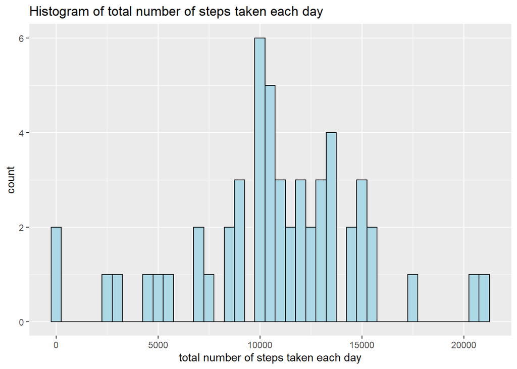

```r
mean_tol <- aggregate(steps~date, df_rena, sum)
g = ggplot(mean_tol, aes(steps))
g + geom_histogram(binwidth = 500, col = "black", fill = "light blue") + labs(title="Histogram of total number of steps taken each day", x="total number of steps taken each day")
```

### 2. Calculate and report the mean and median total number of steps taken per day.

```r
summary(mean_tol$step)
```

```
##    Min. 1st Qu.  Median    Mean 3rd Qu.    Max.
##      41    8841   10765   10766   13294   21194
```

The mean total number of steps taken per day are 10766 and the median total number of steps taken per day are 10765.

## What is the average daily activity pattern?

### 1. produce a time series plot of the of the 5-minute interval (x-axis) and the average number of steps taken, averaged across all days (y-axis)

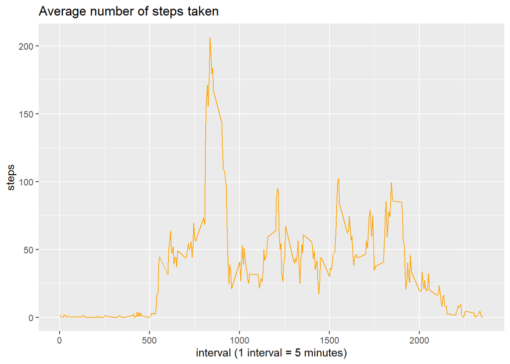

```r
ave_act<- aggregate(steps~interval, df_rena, mean)
g = ggplot(ave_act, aes(interval, steps))
g + geom_line(col = "orange") + labs(title="Average number of steps taken", x="interval (1 interval = 5 minutes)", y = "steps")
```

### 2. Which 5-minute interval, on average across all the days in the dataset, contains the maximum number of steps?

```r
ave_act[which.max(ave_act$steps),]
```

```
##     interval    steps
## 104      835 206.1698
```

The 835 5-minute interval, on average across all the days in the dataset, contains the maximum number of steps of about 206.

## Imputing missing values

```r
# 1. Calculate and report the total number of missing values in the dataset (i.e. the total number of rows with NAs)
colSums(is.na(df))
```

```
##    steps     date interval
##     2304        0        0
```

```r
# 2.Devise a strategy for filling in all of the missing values in the dataset. The strategy does not need to be sophisticated. For example, you could use the mean/median for that day, or the mean for that 5-minute interval, etc.

# 3. Create a new dataset that is equal to the original dataset but with the missing data filled in.
new_df = df
new_df$steps = ifelse(
  is.na(new_df$steps) == TRUE,
  ave_act$steps[ave_act$interval %in% new_df$interval],
  new_df$steps
)
head(new_df)
```

```
##       steps       date interval
## 1 1.7169811 2012-10-01        0
## 2 0.3396226 2012-10-01        5
## 3 0.1320755 2012-10-01       10
## 4 0.1509434 2012-10-01       15
## 5 0.0754717 2012-10-01       20
## 6 2.0943396 2012-10-01       25
```

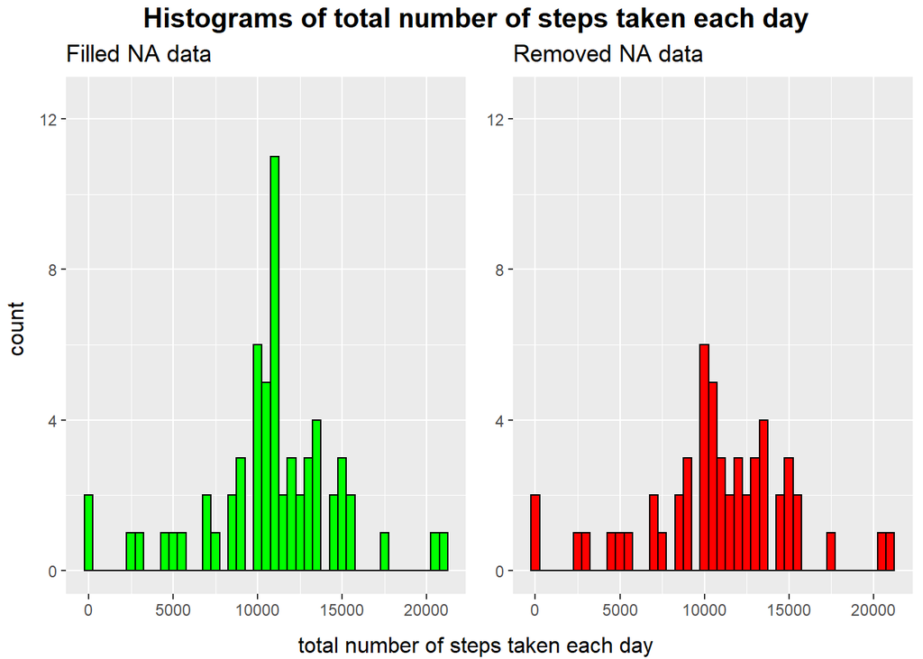

```r
# 4. Make a histogram of the total number of steps taken each day Do these values differ from the estimates from the first part of the assignment? What is the impact of imputing missing data on the estimates of the total daily number of steps?
act_fill <- aggregate(steps~date, new_df, sum)
g = ggplot(act_fill, aes(steps))
plot1 = g + geom_histogram(binwidth = 500, col = "black", fill = "green") + labs(x=NULL,y=NULL, title = "Filled NA data") + ylim(c(0,12.5))
gg = ggplot(mean_tol, aes(steps))
plot2 = gg + geom_histogram(binwidth = 500, col = "black", fill = "red") + labs(x=NULL,y=NULL, title = "Removed NA data") + ylim(c(0,12.5))

annotate_figure(ggarrange(plot1, plot2, ncol=2), top = text_grob("Histograms of total number of steps taken each day", face="bold", size=15), bottom = text_grob("total number of steps taken each day"), left = text_grob("count", rot=90))
```

```r
##Calculate and report the mean and median total number of steps taken per day.
Fill_NA_steps <- summary(act_fill[,2]) # Filled NA data
Removed_NA_steps <- summary(mean_tol[,2]) # Removed NA data
cbind(Fill_NA_steps,Removed_NA_steps)
```

```
##         Fill_NA_steps Removed_NA_steps
## Min.            41.00            41.00
## 1st Qu.       9819.00          8841.00
## Median       10766.19         10765.00
## Mean         10766.19         10766.19
## 3rd Qu.      12811.00         13294.00
## Max.         21194.00         21194.00
```

For Filled NA data: - The mean and median total number of steps taken per day are both 10766.19.

For Removed NA data: - The mean total number of steps taken per day are both 10766.19.

- The median total number of steps taken per day are 10765.

## Are there differences in activity patterns between weekdays and weekends?

```r
# 1. Create a new factor variable in the dataset with two levels – “weekday” and “weekend” indicating whether a given date is a weekday or weekend day.
act_week <- new_df
act_week$day <- as.factor(weekdays(as.Date(act_week$date)))
act_week$wday_weed <- as.factor(ifelse(act_week$day == "Saturday" | act_week$day == "Sunday", "weekend", "weekday"))
head(act_week)
```

```
##       steps       date interval    day wday_weed
## 1 1.7169811 2012-10-01        0 Monday   weekday
## 2 0.3396226 2012-10-01        5 Monday   weekday
## 3 0.1320755 2012-10-01       10 Monday   weekday
## 4 0.1509434 2012-10-01       15 Monday   weekday
## 5 0.0754717 2012-10-01       20 Monday   weekday
## 6 2.0943396 2012-10-01       25 Monday   weekday
```

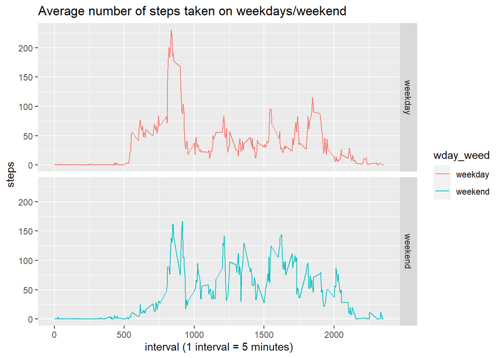

```r
# 2. Make a panel plot containing a time series plot (i.e. type = “l”) of the 5-minute interval (x-axis) and the average number of steps taken, averaged across all weekday days or weekend days (y-axis).
week_data <- aggregate(steps~interval + wday_weed, act_week, mean)
g = ggplot(week_data, aes(colour= wday_weed, x=interval, y=steps))
g + geom_line()+labs(x="interval (1 interval = 5 minutes)", y="steps", title="Average number of steps taken on weekdays/weekend") + facet_grid(wday_weed ~ .)
```